# Central_limit_theorem and Z test

Xuening

4/11/2020

## Central limit theorem

Suppose $X_1,X_2,...,X_n$ is a random sample of size $n$ taken from a population with mean $\mu$ and finite variance $\sigma^2$. If $\bar{X}=\frac{1}{n}\sum_{i=1}^n X_i$, then as $n \rightarrow \infty$, $\bar{X}$ observes normal distribution with mean $\mu$ and standard deviation$\sigma/\sqrt{n}$. That is to say, the distribution of $Z=\frac{\bar{X}-\mu}{\sigma/\sqrt{n}}$ is a standard normal distribution. The value of $Z$ is also called Z-statistic or Z-score.

## Power of central limit theorem

The population may observe whatever distribution. But when the sample size $n$ is large enough, normal distribution can describe the distribution of sample mean pretty well. This give us the ability to calculate confidence interval, t-statistics and others without knowing the distribution of population.

How large is large enough for sample size? Usually 30 is picked as threshold, but the distribution of population and other factors also influence this threshold.

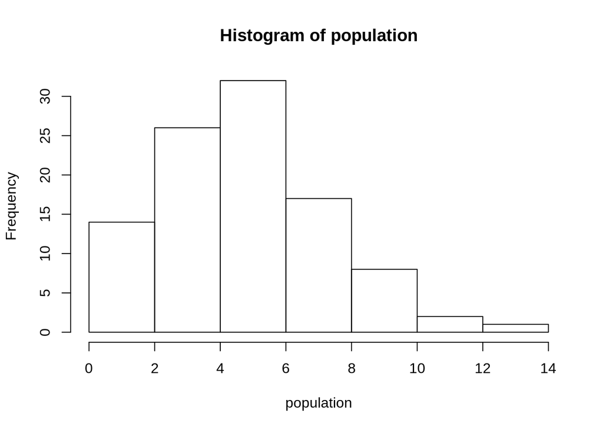

```r
population <- rpois(100,5) # 1000 samples
hist(population)
```

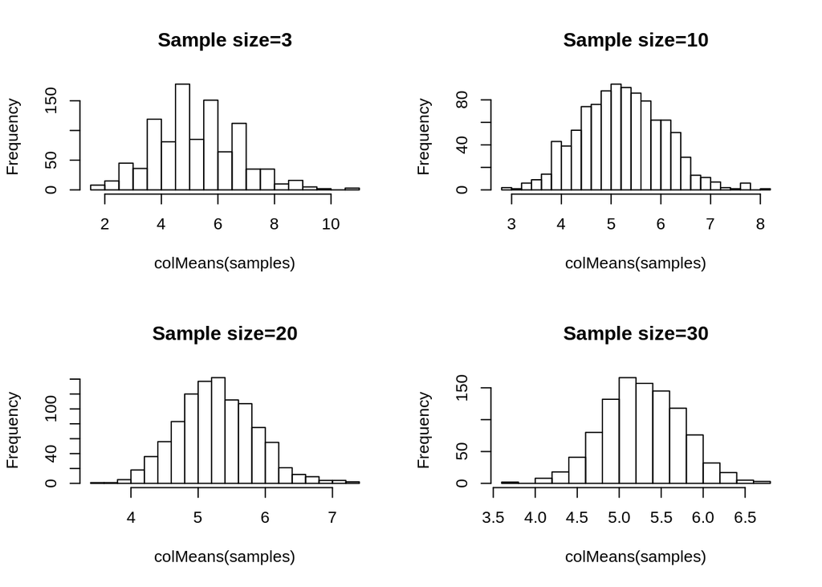

```r
#create sample of size=3, 10,20,30
sizes <- c(3,10,20,30)
par(mfrow=c(2,2))
for (size in sizes){
        samples <- replicate(1000,sample(population,size,replace=T))
        hist(colMeans(samples),main=paste0("Sample size=",size),breaks = 20)
}
```

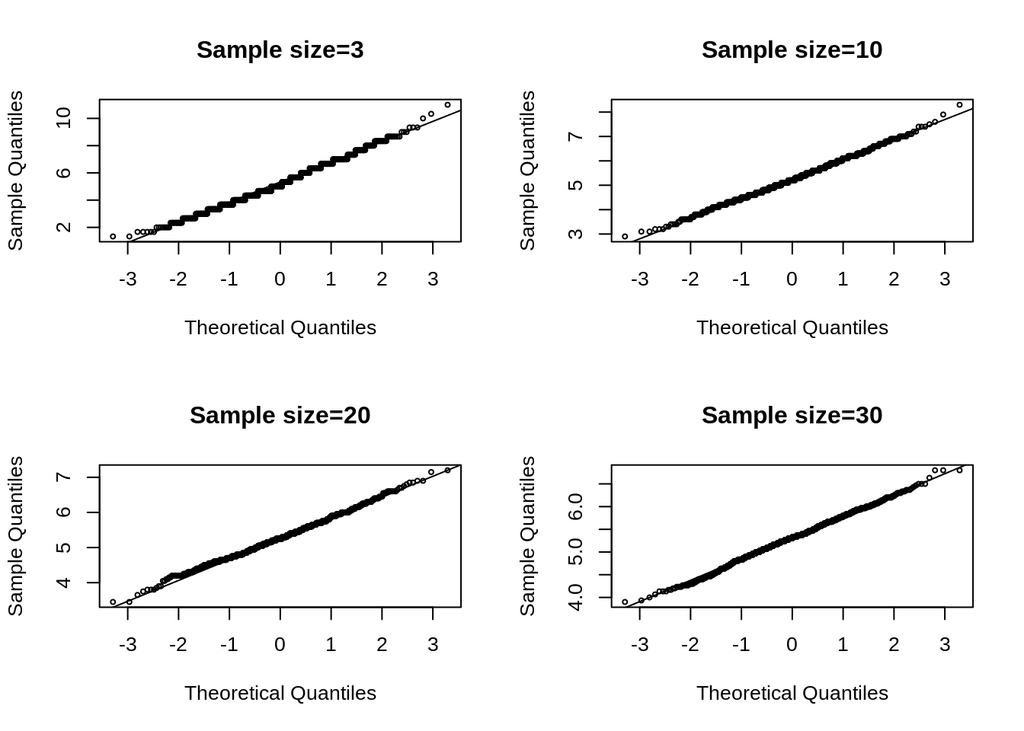

```r
#using quantiles to compare with normal distribution
par(mfrow=c(2,2))
for (size in sizes){
        samples <- replicate(1000,sample(population,size,replace=T))
        qqnorm(colMeans(samples),main=paste0("Sample size=",size),cex=0.5)
        qqline(colMeans(samples))
}
```

## Z test

As we’ve said, let $Z=\frac{\bar{X}-\mu}{\sigma/\sqrt{n}}$, then Z observes normal distribution. Theoretically, Z test is used when population variance is known and sample size is large. However, in practice Z test is used as long as sample size is large, even if population variance is unknown.

When sample size is small, t-test is more appropriate.